# Math Anxiety Initial Modeling

Emi

2023-04-23

# Load Tidyverse

```r
library(tidyverse)
```

# Load clean data

```r
df <- read.csv("../../data/clean2.csv")
head(df)
```

```
##   subjectid cond race tma si mw1 mw2 under_avg worry0 enjoy0    worry1   enjoy1
## 1     Aq001    0   NA  11 NA 3.0  NA  78.57143      2      0 1.8333333 1.333333
## 2    Aq002a    1    4  10 54 2.2 1.6  81.42857      1      3 0.1666667 3.500000
## 3     Aq003    1    4   9 36 2.0 1.8  83.85714      3      4 2.6666667 3.166667
## 4     Aq004    1    4   8 39 3.0 1.6  84.28571      1      3 0.3333333 1.500000
## 5    Aq005a    1    4   8 54 2.0 2.0  66.00000      1      4 1.1666667 3.333333
## 6     Aq006    0   NA  NA NA 1.4  NA  27.42857      1      4 0.3333333 3.166667
##      worry2   enjoy2   HOT X race_rv gender chicago base_enjoy base_worry
## 1 2.0000000 2.000000 0.375 1       1      0       1          0          2
## 2 0.0000000 4.000000 0.500 2       4      0       1          3          1
## 3 0.6666667 1.333333 0.875 3       4      0       1          4          3
## 4 1.0000000 1.333333 0.000 4       4      0       1          3          1
## 5 0.0000000 3.666667 0.750 5       4      1       1          4          1
## 6        NA       NA 0.500 6       4      1       1          4          1
##   tma_sum_rv cries_sum_rv worry_durimm_avg worry_del_avg enjoy_del_avg
## 1  11.000000            8         1.833330     2.0000000      2.000000
## 2  10.000000            4         0.166667     0.0000000      4.000000
## 3   9.000000           10         2.666670     0.6666670      1.333330
## 4   8.000000            6         0.333333     1.0000000      1.333330
## 5   8.000000            5         1.166670     0.0000000      3.666670
## 6   8.179096            5         0.333333     0.3728205      2.778308
##   enjoy_durimm_avg understand_avg mw_day1_sum mw_day2_sum   si_sum
## 1          1.33333        78.5714          15   13.418452 39.92667
## 2          3.50000        81.4286          11    8.000000 54.00000
## 3          3.16667        83.8571          10    9.000000 36.00000
## 4          1.50000        84.2857          15    8.000000 39.00000
## 5          3.33333        66.0000          10   10.000000 54.00000
## 6          3.16667        27.4286           7    8.708517 47.03650
```

```r
glimpse(df)
```

```
## Rows: 280
## Columns: 31
## $ subjectid        <chr> "Aq001", "Aq002a", "Aq003", "Aq004", "Aq005a", "Aq006…
## $ cond             <int> 0, 1, 1, 1, 1, 0, 0, 1, 1, 0, 0, 1, 0, 1, 0, 1, 0, 0,…
## $ race             <int> NA, 4, 4, 4, 4, NA, 4, 1, 5, NA, 5, NA, 1, 5, 4, 5, N…
## $ tma              <int> 11, 10, 9, 8, 8, NA, 9, 9, 7, 6, 7, 14, 5, 11, 8, 7, …
## $ si               <int> NA, 54, 36, 39, 54, NA, 57, 55, 55, NA, 44, NA, 51, 5…
## $ mw1              <dbl> 3.0, 2.2, 2.0, 3.0, 2.0, 1.4, 1.8, 1.2, 2.6, 2.6, 1.0…
## $ mw2              <dbl> NA, 1.6, 1.8, 1.6, 2.0, NA, 1.2, 1.2, 1.6, NA, 1.4, N…
## $ under_avg        <dbl> 78.57143, 81.42857, 83.85714, 84.28571, 66.00000, 27.…
## $ worry0           <int> 2, 1, 3, 1, 1, 1, 0, 0, 0, 0, 0, 0, 1, 0, 0, 1, 0, 0,…
## $ enjoy0           <int> 0, 3, 4, 3, 4, 4, 3, 4, 4, 4, 4, 0, 3, 2, 3, 2, 4, 2,…
## $ worry1           <dbl> 1.8333333, 0.1666667, 2.6666667, 0.3333333, 1.1666667…
## $ enjoy1           <dbl> 1.3333333, 3.5000000, 3.1666667, 1.5000000, 3.3333333…
## $ worry2           <dbl> 2.0000000, 0.0000000, 0.6666667, 1.0000000, 0.0000000…
```

[output cut: 18 more lines]

# Modeling

For each model, we are using same dependent variable and list of independent variables:

**Dependent variable:** Mathematical anxiety `tma`

## Normal Regression Model

### Model 1.1

```r
m1_1 <- df %>%
        lm(formula = tma ~ cond + mw1 + mw2 + under_avg + HOT + under_avg + si_sum)
summary(m1_1)
```

```
##
## Call:
## lm(formula = tma ~ cond + mw1 + mw2 + under_avg + HOT + under_avg +
##     si_sum, data = .)
##
## Residuals:
##     Min      1Q  Median      3Q     Max
## -9.1892 -2.3969 -0.7633  2.1022 13.2150
##
## Coefficients:
##              Estimate Std. Error t value Pr(>|t|)
## (Intercept)  9.864957   1.723360   5.724 3.52e-08 ***
## cond         0.158178   0.506970   0.312   0.7553
## mw1          0.771147   0.316484   2.437   0.0157 *
## mw2          0.554814   0.334306   1.660   0.0985 .
## under_avg   -0.003282   0.012691  -0.259   0.7962
## HOT         -0.465931   1.102162  -0.423   0.6729
## si_sum      -0.058066   0.023860  -2.434   0.0158 *
## ---
## Signif. codes:  0 '***' 0.001 '**' 0.01 '*' 0.05 '.' 0.1 ' ' 1
##
## Residual standard error: 3.653 on 212 degrees of freedom
##   (61 observations deleted due to missingness)
## Multiple R-squared:  0.1503, Adjusted R-squared:  0.1263
## F-statistic: 6.251 on 6 and 212 DF,  p-value: 4.595e-06
```

### Model 1.2: Take the average of mind wandering

```r
# Take the average of mind wandering day 1 and day 2
df <- df %>%
        mutate( mw_avg = rowMeans(df[6:7], na.rm = TRUE))
```

```r
m1_2 <- df %>%
        lm(formula = tma ~ cond + mw_avg + under_avg + HOT + under_avg + si_sum)
summary(m1_2)
```

```
##
## Call:
## lm(formula = tma ~ cond + mw_avg + under_avg + HOT + under_avg +
##     si_sum, data = .)
##
## Residuals:
##     Min      1Q  Median      3Q     Max
## -9.4920 -2.4071 -0.9003  2.2221 13.4809
##
## Coefficients:
##               Estimate Std. Error t value Pr(>|t|)
## (Intercept)  9.736e+00  1.714e+00   5.680 4.06e-08 ***
## cond         3.139e-01  5.005e-01   0.627  0.53114
## mw_avg       1.413e+00  3.076e-01   4.595 7.15e-06 ***
## under_avg   -4.508e-05  1.252e-02  -0.004  0.99713
## HOT         -1.093e-01  1.040e+00  -0.105  0.91636
## si_sum      -6.898e-02  2.368e-02  -2.914  0.00393 **
## ---
## Signif. codes:  0 '***' 0.001 '**' 0.01 '*' 0.05 '.' 0.1 ' ' 1
##
## Residual standard error: 3.738 on 229 degrees of freedom
##   (45 observations deleted due to missingness)
## Multiple R-squared:  0.164,  Adjusted R-squared:  0.1458
## F-statistic: 8.986 on 5 and 229 DF,  p-value: 8.206e-08
```

Features that have significant effects on math anxiety (p < 0.05): `mw_1_avg` (positive effect: 1.413) and `si_sum` (negative effect: -6.898e-02)

### Model 1.3: Take the ratio of day 1 and day 2

```r
# Take the ratio of mw1 and mw2
df <- df %>%
        mutate(mw_ratio  = case_when(
          is.na(mw1) & is.na(mw2) ~ 0,
          is.na(mw1) | is.na(mw2) ~ 1,
          !is.na(mw1) & !is.na(mw2) ~ mw1 / mw2) )
```

```r
m1_3 <- df %>%
        lm(formula = tma ~ cond + mw_ratio + under_avg + HOT + under_avg + si_sum)
summary(m1_3)
```

```
##
## Call:
## lm(formula = tma ~ cond + mw_ratio + under_avg + HOT + under_avg +
##     si_sum, data = .)
##
## Residuals:
##     Min      1Q  Median      3Q     Max
## -8.6559 -2.7185 -0.9138  2.1516 16.5414
##
## Coefficients:
##             Estimate Std. Error t value Pr(>|t|)
## (Intercept) 14.95989    1.44604  10.345  < 2e-16 ***
## cond         0.02446    0.52057   0.047 0.962562
## mw_ratio     0.24525    0.49954   0.491 0.623929
## under_avg   -0.01946    0.01233  -1.579 0.115784
## HOT         -0.52057    1.08451  -0.480 0.631684
## si_sum      -0.08654    0.02440  -3.546 0.000473 ***
## ---
## Signif. codes:  0 '***' 0.001 '**' 0.01 '*' 0.05 '.' 0.1 ' ' 1
##
## Residual standard error: 3.905 on 229 degrees of freedom
##   (45 observations deleted due to missingness)
## Multiple R-squared:  0.0879, Adjusted R-squared:  0.06799
## F-statistic: 4.414 on 5 and 229 DF,  p-value: 0.0007405
```

Features that have significant effects on math anxiety (p < 0.05): `si_sum` (negative effect: -0.08654)

### Model 1.4: Take the percent change of mw1 and mw2

$$mw_c = \frac{mw2 -
mw1}{mw1}$$

```r
# Taking the percent change of mw1 and mw2
df <- df %>%
        mutate(mw_ratio  = case_when(
          is.na(mw1) | is.na(mw2) ~ 0,
          !is.na(mw1) & !is.na(mw2) ~ (mw2 - mw1) / mw1) )
```

```r
m1_4 <- df %>%
        lm(formula = tma ~ cond + mw_ratio + under_avg + HOT + under_avg + si_sum)
summary(m1_4)
```

```
##
## Call:
## lm(formula = tma ~ cond + mw_ratio + under_avg + HOT + under_avg +
##     si_sum, data = .)
##
## Residuals:
##     Min      1Q  Median      3Q     Max
## -8.7565 -2.6810 -0.9704  2.1328 17.0070
##
## Coefficients:
##             Estimate Std. Error t value Pr(>|t|)
## (Intercept) 15.30676    1.26875  12.064  < 2e-16 ***
## cond         0.04472    0.51977   0.086 0.931506
## mw_ratio     0.04649    0.76556   0.061 0.951632
## under_avg   -0.02008    0.01228  -1.635 0.103502
## HOT         -0.48016    1.08964  -0.441 0.659873
## si_sum      -0.08690    0.02459  -3.535 0.000494 ***
## ---
## Signif. codes:  0 '***' 0.001 '**' 0.01 '*' 0.05 '.' 0.1 ' ' 1
##
## Residual standard error: 3.907 on 229 degrees of freedom
##   (45 observations deleted due to missingness)
## Multiple R-squared:  0.08696,    Adjusted R-squared:  0.06702
## F-statistic: 4.362 on 5 and 229 DF,  p-value: 0.0008216
```

Features that have significant effects on math anxiety (p < 0.05): `si_sum` (negative effect: -0.08690)

### Model 1.5: Add interaction effects

We will consider worked example group as our interaction effects on the independent variables

Consider the following model:

`tma ~ cond + mw_avg + si_sum + mw_avg * cond + si_sum * cond`

```r
m1_5 <- df %>%
        lm(formula = tma ~ cond + mw_avg + si_sum + mw_avg * cond + si_sum * cond)
summary(m1_5)
```

```
##
## Call:
## lm(formula = tma ~ cond + mw_avg + si_sum + mw_avg * cond + si_sum *
##     cond, data = .)
##
## Residuals:
##      Min       1Q   Median       3Q      Max
## -10.3872  -2.3111  -0.8327   2.1284  13.2722
##
## Coefficients:
##             Estimate Std. Error t value Pr(>|t|)
## (Intercept) 11.70201    1.89720   6.168  3.1e-09 ***
## cond        -3.21286    2.56232  -1.254 0.211160
## mw_avg       1.36529    0.36534   3.737 0.000235 ***
## si_sum      -0.11611    0.03391  -3.424 0.000730 ***
## cond:mw_avg -0.21192    0.59449  -0.356 0.721814
## cond:si_sum  0.09319    0.04640   2.008 0.045780 *
## ---
## Signif. codes:  0 '***' 0.001 '**' 0.01 '*' 0.05 '.' 0.1 ' ' 1
##
## Residual standard error: 3.701 on 229 degrees of freedom
##   (45 observations deleted due to missingness)
## Multiple R-squared:  0.1807, Adjusted R-squared:  0.1628
## F-statistic:  10.1 on 5 and 229 DF,  p-value: 9.322e-09
```

Features that have significant effects on math anxiety (p < 0.05): `mw_avg` (positive effect: 1.36529) `si_sum` (Negative effect: -0.11611), and `cond:si_sum` (small positive effect: 0.09319)

# Findings

- Not enough evidence to suggest that worked examples have significant effects on students’ mathematical anxiety levels
- Taking the average of `mw1` and `mw2` resulted in better model compared to the ratio or percent change
- Two features that had significant effects on math anxiety were: `mw_avg` and `si_sum`. Indicating that average mind wandering have positive impact on math anxiety and situational interest has negative impact on math anxiety
- Very small effect on math anxiety by `cond:si_sum`, the interaction effect of worked example with situational interests. Situational interests may differ in each study group (small chance).

# Visualizations

## Mind wanering average vs math anxiety

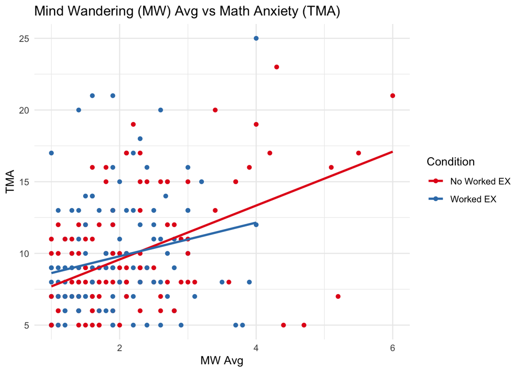

```r
df %>%
  ggplot(aes(x = mw_avg, y = tma, color = as.factor(cond))) +
  geom_point() + geom_smooth(method = "lm", se = FALSE) +
  labs(title = "Mind Wandering (MW) Avg vs Math Anxiety (TMA)", x = "MW Avg", y = "TMA",
       color = "Condition") +
  scale_color_brewer(palette="Set1", labels =
                      c("No Worked EX", "Worked EX")) +
  theme_minimal()
```

## SI sum vs math anxiety

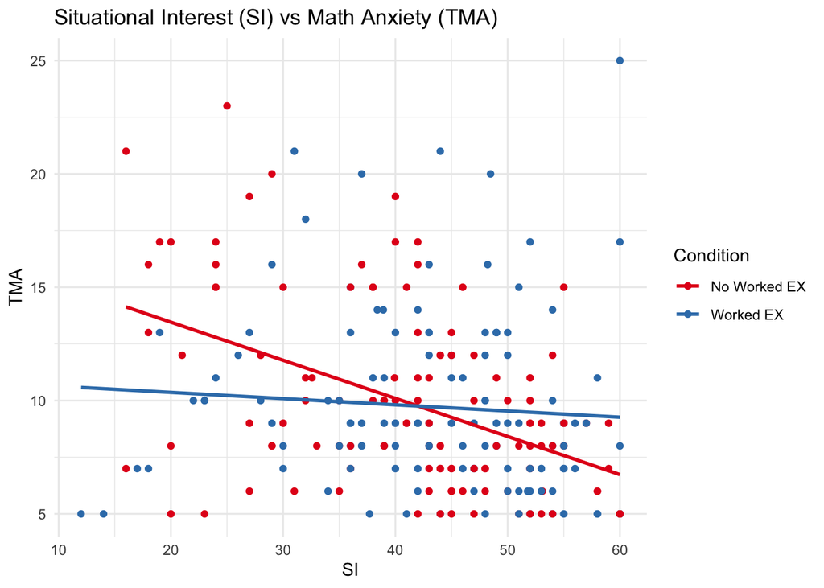

```r
df %>%
  ggplot(aes(x = si_sum, y = tma, color = as.factor(cond))) +
  geom_point() + geom_smooth(method = "lm", se = FALSE) +
  labs(title = "Situational Interest (SI) vs Math Anxiety (TMA)", x = "SI", y = "TMA",
       color = "Condition") +
  scale_color_brewer(palette="Set1", labels =
                      c("No Worked EX", "Worked EX")) +
  theme_minimal()
```